# The Middle Income Trap

# 1. Background

1.1 Definitions

Per Capital GNI (Gross National Income:GNI)

- Lower Middle Income: between $1,036 and $4,045
- Upper Middle Income: between $4,046 and $12,535

Source: [World Bank’s Definition](https://www.worldbank.org/en/country/mic/overview)

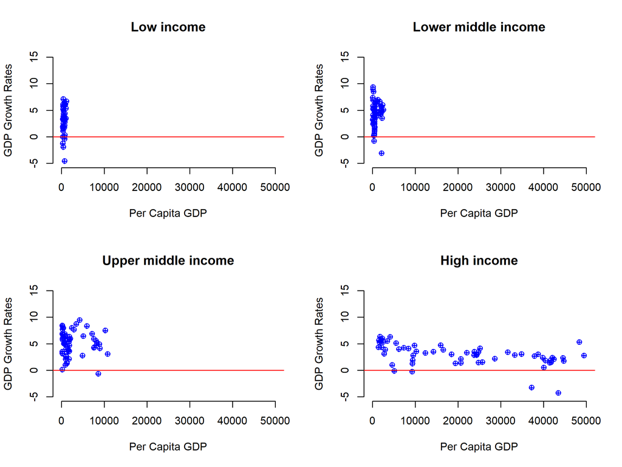

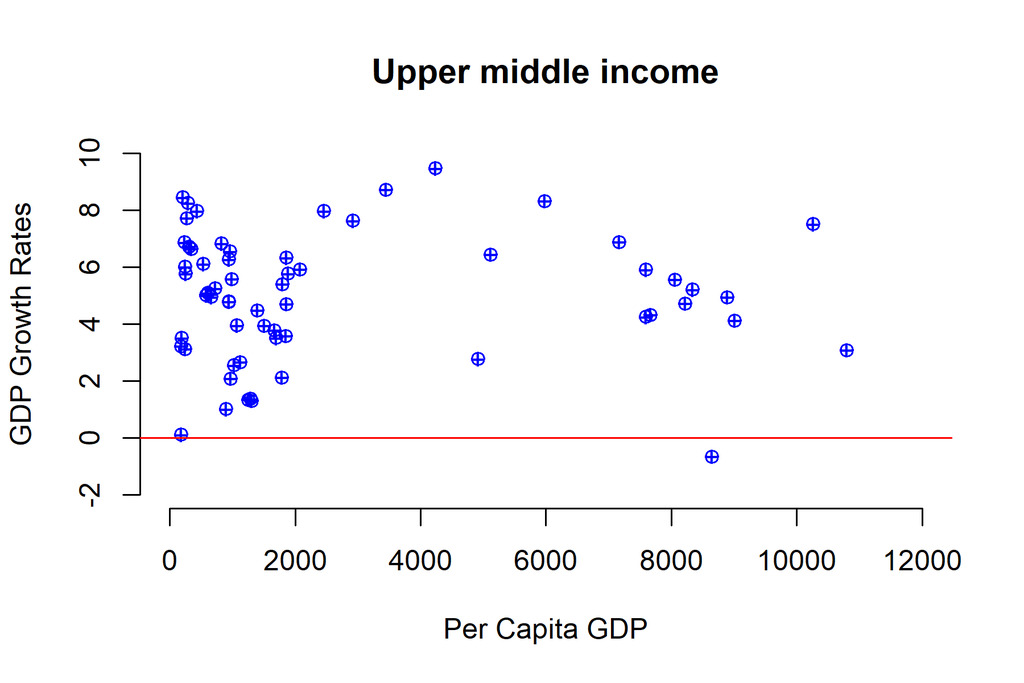

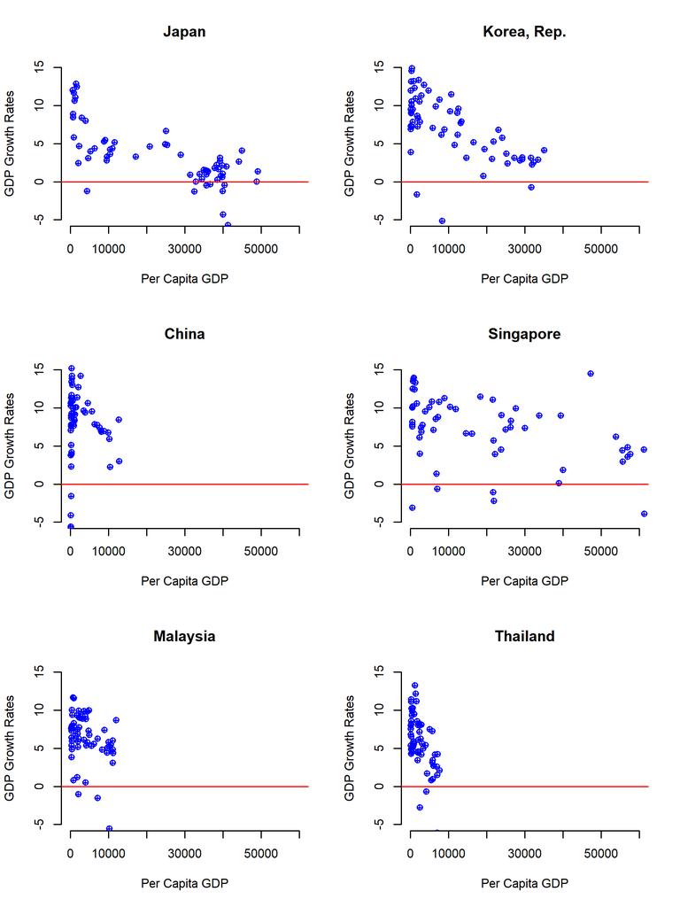

1.2 Why does it take so long for many countries to reach per capita GNI of $10,000?

[Per Capita GNI (USD, Constant, 2010)](https://data.worldbank.org/indicator/NY.GNP.PCAP.KD?locations=JP-CN-KR-MN-KH-BN-ID-LA-MY-MM-PH-SG-TH-VN)

# 2. Theoretical Background

What does the theories say about the cause of middle income trap?

- The causes of slowing down
  - [The Myth of ASIA’S Miracle (Krugman, 1997) argued that Asian growths were essentially input-driven and deemed to slowdown](https://www.gsid.nagoya-u.ac.jp/sotsubo/Krugman.pdf)
  - [Lack of public goods and innovation (Hayami, 1997)](https://www.ide.go.jp/library/English/Publish/Periodicals/De/pdf/98_01_05.pdf)
  - [An East Asian Renaissance (Griffi, 2007) coined the term “middle income trap” and identified (i) congestion, (ii) conflict, and (iii) corruption as the causes of slowing down](https://openknowledge.worldbank.org/server/api/core/bitstreams/5c7eaa0e-8a31-5726-ba94-f079c970c870/content)
  - [The middle income trap from a China and ASEAN perspective (Tran and Karikomi, 2019) reviewed by Ohno (2020) which devides growths into (i) factor-accumulation-driven quantitative growth (first stage), and (2) technical-progress-driven qualitative growth (second stage)](https://www.tandfonline.com/doi/full/10.1080/24761028.2020.1726554)

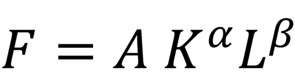

Production function. A: Technology, K: Capital, L: Labor

- e.g. amost any countries can manufacture horse carts, oxcarts but only a few can produce cars.

- Car requires far more number of parts (e.g. A Toyota car is made of about 30,000 parts)
- Most of these parts are different and more sophisticated

# 3. The chanllenge is how?

Often observed misconceptions in developing countries

- Innovation cannot be taught. Innovation is literally unknown knowledge, technology, …
  - Among countries with significant gold medals in International Math Olympiad, less innovative countries seem to do better. [medal ranking by countries](https://www.imo-official.org/results_country.aspx)
  - [International Physics Olympiad Cummulative Results by Countries] (https://en.wikipedia.org/wiki/International_Physics_Olympiad)
- Growth comes from division of labor, not self-sufficiency. Employees in modern societies increase productivity through acquiring skills to make use of combination of tools.
  - [Doraemon under attack as a bad influence on children in India Pakistan (NIKKEI, 2016)](https://asia.nikkei.com/Politics/Doraemon-under-attack-as-a-bad-influence-on-children-in-India-Pakistan2#:~:text=NEW%20DELHI%20%2D%2D%20Beloved%20Japanese,the%20popular%20character%20from%20television.)
- Per capita growth comes from working less, not more
  - [average working hour per year (OECD)](https://stats.oecd.org/Index.aspx?DataSetCode=ANHRS)
    - [Karoshi (Japantimes)](https://www.japantimes.co.jp/tag/karoshi/)
    - [South korea work hour (CNN)](https://edition.cnn.com/2018/07/02/health/south-korea-work-hours/index.html)
    - [China 996 (BBC)](https://www.bbc.com/worklife/article/20190718-china-996)